# seaborn

## Seaborn: matplotlib for the masses

An interesting new addition to the python scientific libraries is Seaborn; this graphical library is built on top of matplotlib, providing interesting styles and plotting routines.

The library is a mixture of handy style functions, handy and better plots, and even analysis tools.

```python
# Ipython stuff to get plots in the notebook
%matplotlib inline

# Import numpy to generate some numbers
import numpy as np
```

```python
# Import matplotlib
import matplotlib.pyplot as plt
```

```python
# Read some example data
x = [float(l.strip().split()[0]) for l in open('test.tsv')]
y = [float(l.strip().split()[1]) for l in open('test.tsv')]

def logistic(x, A=404.45, u=10.73, d=11.96, v=0.1, y0=-40.64):
    '''
    Logistic growth model
    Taken from: "Modeling of the bacterial growth curve."
                (Zwietering et al., 1990)
                PMID: 16348228
    '''
    y = (A / (1 + np.exp( ( ((4 * u)/A) * (d - x) ) + 2 ))) + y0
    return y

def gompertz(x, A=404.45, u=10.73, d=11.96, v=0.1, y0=-10.64):
    '''
    Gompertz growth model
    Taken from: "Modeling of the bacterial growth curve."
                (Zwietering et al., 1990)
                PMID: 16348228
    '''
    y = (A * np.exp( -np.exp( (((u * np.e)/A) * (d - x)) + 1 ) ) ) + y0
    return y

def richards(x, A=404.45, u=12.73, d=11.96, v=1, y0=-30.64):
    '''
    Richards growth model
    (equivalent to Stannard)
    Taken from: "Modeling of the bacterial growth curve."
                (Zwietering et al., 1990)
                PMID: 16348228
    '''
    y = (A * pow(1 + (v + (np.exp(1 + v) * np.exp( (u/A) * (1 + v) * (1 + (1/v)) * (d - x) ) ) ),-(1/v))) + y0
    return y
```

```python
def plot_curves(x, y):
    x1 = np.linspace(0, max(x), 1000)

    plt.plot(x,
             y,
             '+r',
             lw=2,
             label='Original data')

    plt.plot(x1,
             logistic(x1),
             '-b',
             lw=2,
             alpha=0.6,
             label='Logistic fit')

    plt.plot(x1,
             gompertz(x1),
             '-g',
             lw=2,
             alpha=0.6,
             label='Gompertz fit')

    plt.plot(x1,
             richards(x1),
             '-y',
             lw=2,
             alpha=0.6,
             label='Richards fit')

    plt.xlabel('Time (h)')
    plt.ylabel('Signal (units)')

    plt.legend(loc='best')
```

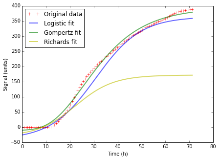

```python
plt.figure(figsize=(7, 5))

plot_curves(x, y)

# Avoid the prompt
pass
```

```python
# Here it comes!
import seaborn as sns
```

## Styles as context managers

*Please note that the subplot function must be inside the context manager*

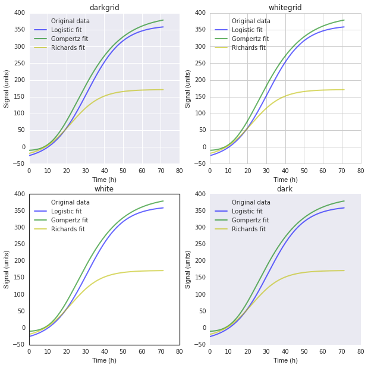

```python
plt.figure(figsize=(10, 10))

with sns.axes_style('darkgrid'):
    plt.subplot(2, 2, 1)
    plot_curves(x, y)
plt.title('darkgrid')

with sns.axes_style('whitegrid'):
    plt.subplot(2, 2, 2)
    plot_curves(x, y)
plt.title('whitegrid')

with sns.axes_style('white'):
    plt.subplot(2, 2, 3)
    plot_curves(x, y)
plt.title('white')

with sns.axes_style('dark'):
    plt.subplot(2, 2, 4)
    plot_curves(x, y)
plt.title('dark')

# Avoid the prompt
pass
```

## Handy style functions: despine

*Here we set the style directly: it can be reverted to the default one ("darkgrid") with the set function*

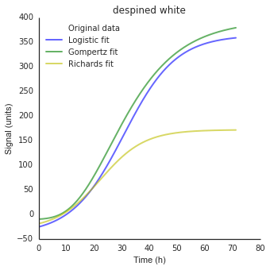

```python
plt.figure(figsize=(5, 5))

sns.set_style('white')
plot_curves(x, y)
sns.despine()
plt.title('despined white')

sns.set_style()

# Avoid text prompt
pass
```

## Color schemes (as context managers!)

*Really useful for gradients*

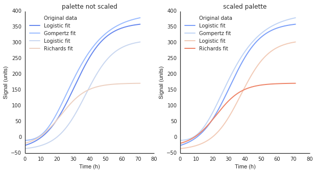

```python
plt.figure(figsize=(10, 5))

with sns.color_palette("coolwarm"):
    plt.subplot(1, 2, 1)
    sns.set_style('white')
    x1 = np.linspace(0, max(x), 1000)

    plt.plot(x,
             y,
             '+r',
             lw=2,
             label='Original data')

    plt.plot(x1,
             logistic(x1),
             lw=2,
             label='Logistic fit')

    plt.plot(x1,
             gompertz(x1),
             lw=2,
             label='Gompertz fit')

    plt.plot(x1,
             logistic(x1,
                      350.,
                      10.,
                      20.),
             lw=2,
             label='Logistic fit')

    plt.plot(x1,
             richards(x1),
             lw=2,
             label='Richards fit')

    plt.xlabel('Time (h)')
    plt.ylabel('Signal (units)')

    plt.legend(loc='best')
    sns.despine()
    plt.title('palette not scaled')

with sns.color_palette("coolwarm", 4):
    plt.subplot(1, 2, 2)
    sns.set_style('white')
    x1 = np.linspace(0, max(x), 1000)

    plt.plot(x,
             y,
             '+r',
             lw=2,
             label='Original data')

    plt.plot(x1,
             logistic(x1),
             lw=2,
             label='Logistic fit')

    plt.plot(x1,
             gompertz(x1),
             lw=2,
             label='Gompertz fit')

    plt.plot(x1,
             logistic(x1,
                      350.,
                      10.,
                      20.),
             lw=2,
             label='Logistic fit')

    plt.plot(x1,
             richards(x1),
             lw=2,
             label='Richards fit')

    plt.xlabel('Time (h)')
    plt.ylabel('Signal (units)')

    plt.legend(loc='best')
    sns.despine()
    plt.title('scaled palette')

# Avoid text prompt
pass
```

## New plots: violinplot

Just a stylistic change, but a quite interesting one. Also, better boxplots!

```python
x = np.random.normal(0, 1, 1000)
x1 = np.random.normal(1, 3, 1000)
x2 = np.random.normal(2, 4, 1000)
```

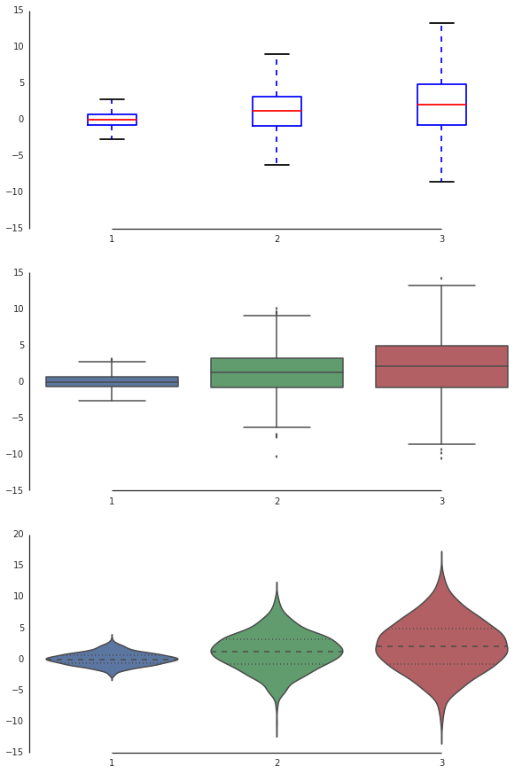

```python
plt.figure(figsize=(10, 15))

plt.subplot(3, 1, 1)
plt.boxplot([x, x1, x2])
sns.despine()

plt.subplot(3, 1, 2)
sns.boxplot([x, x1, x2])
sns.despine(trim=True)

plt.subplot(3, 1, 3)
sns.violinplot([x, x1, x2])
sns.despine(trim=True)
```

## Visualizing distributions, with some Pandas on the side

Plotting a density estimation of the data has become much easier than using directly scipy or scikit.learn

[output not shown]

[figure not shown]

```python
plt.figure(figsize=(7, 5))

# Beware if you have a list of numbers and not an array
import random
y = [random.random() for i in range(100)]

sns.kdeplot(y, shade=True)
sns.despine()
```

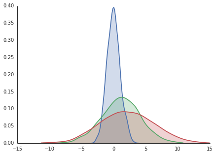

```python
plt.figure(figsize=(7, 5))

sns.kdeplot(x, shade=True)
sns.kdeplot(x1, shade=True)
sns.kdeplot(x2, shade=True)
sns.despine()
```

A rug plot is also very useful to check whether the density function has been computed on a good distributions of data points.

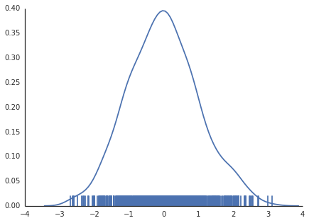

```python
plt.figure(figsize=(7, 5))

sns.distplot(x, rug=True, hist=False)
sns.despine()
```

The kdeplot can also go 2d, comparing the relative distribution of two datasets

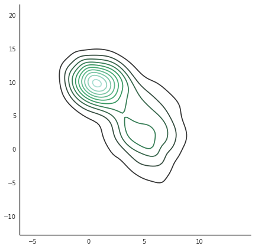

```python
plt.figure(figsize=(7, 7))

x3 = np.concatenate((np.random.normal(1, 1.5, 1000), np.random.normal(5, 2, 1000)))
x4 = np.concatenate((np.random.normal(10, 2, 1000), np.random.normal(3, 4, 1000)))

sns.kdeplot(x3, x4)
sns.despine()
pass
```

The jointplot will also give you the correlation coefficient

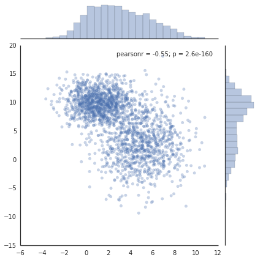

```python
plt.figure(figsize=(7, 7))

x3 = np.concatenate((np.random.normal(1, 1.5, 1000), np.random.normal(5, 2, 1000)))
x4 = np.concatenate((np.random.normal(10, 2, 1000), np.random.normal(3, 4, 1000)))

sns.jointplot(x3, x4, joint_kws={'alpha':0.3})
pass
```

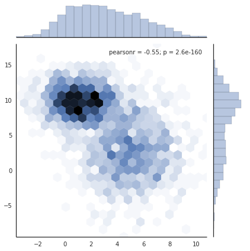

```python
plt.figure(figsize=(7, 7))

sns.jointplot(x3, x4, kind='hex')
pass
```

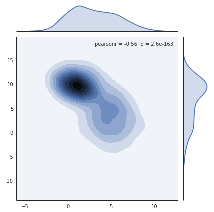

```python
plt.figure(figsize=(7, 7))

sns.jointplot(x3, x4, kind='kde')
pass
```

The lmplot function lets you apply linear models to pandas dataframes, by separating the data according to the values in their columns.

```python
tips = sns.load_dataset("tips")
```

```python
tips
```

|  | total_bill | tip | sex | smoker | day | time | size |
| --- | --- | --- | --- | --- | --- | --- | --- |
| 0 | 16.99 | 1.01 | Female | No | Sun | Dinner | 2 |
| 1 | 10.34 | 1.66 | Male | No | Sun | Dinner | 3 |
| 2 | 21.01 | 3.50 | Male | No | Sun | Dinner | 3 |
| 3 | 23.68 | 3.31 | Male | No | Sun | Dinner | 2 |
| 4 | 24.59 | 3.61 | Female | No | Sun | Dinner | 4 |
| 5 | 25.29 | 4.71 | Male | No | Sun | Dinner | 4 |
| 6 | 8.77 | 2.00 | Male | No | Sun | Dinner | 2 |
| 7 | 26.88 | 3.12 | Male | No | Sun | Dinner | 4 |
| 8 | 15.04 | 1.96 | Male | No | Sun | Dinner | 2 |
| 9 | 14.78 | 3.23 | Male | No | Sun | Dinner | 2 |
| 10 | 10.27 | 1.71 | Male | No | Sun | Dinner | 2 |
| 11 | 35.26 | 5.00 | Female | No | Sun | Dinner | 4 |
| 12 | 15.42 | 1.57 | Male | No | Sun | Dinner | 2 |
| 13 | 18.43 | 3.00 | Male | No | Sun | Dinner | 4 |
| 14 | 14.83 | 3.02 | Female | No | Sun | Dinner | 2 |
| 15 | 21.58 | 3.92 | Male | No | Sun | Dinner | 2 |
| 16 | 10.33 | 1.67 | Female | No | Sun | Dinner | 3 |
| 17 | 16.29 | 3.71 | Male | No | Sun | Dinner | 3 |
| 18 | 16.97 | 3.50 | Female | No | Sun | Dinner | 3 |
| 19 | 20.65 | 3.35 | Male | No | Sat | Dinner | 3 |
| 20 | 17.92 | 4.08 | Male | No | Sat | Dinner | 2 |
| 21 | 20.29 | 2.75 | Female | No | Sat | Dinner | 2 |
| 22 | 15.77 | 2.23 | Female | No | Sat | Dinner | 2 |
| 23 | 39.42 | 7.58 | Male | No | Sat | Dinner | 4 |
| 24 | 19.82 | 3.18 | Male | No | Sat | Dinner | 2 |
| 25 | 17.81 | 2.34 | Male | No | Sat | Dinner | 4 |
| 26 | 13.37 | 2.00 | Male | No | Sat | Dinner | 2 |
| 27 | 12.69 | 2.00 | Male | No | Sat | Dinner | 2 |
| 28 | 21.70 | 4.30 | Male | No | Sat | Dinner | 2 |
| 29 | 19.65 | 3.00 | Female | No | Sat | Dinner | 2 |
| 30 | 9.55 | 1.45 | Male | No | Sat | Dinner | 2 |
| 31 | 18.35 | 2.50 | Male | No | Sat | Dinner | 4 |
| 32 | 15.06 | 3.00 | Female | No | Sat | Dinner | 2 |
| 33 | 20.69 | 2.45 | Female | No | Sat | Dinner | 4 |
| 34 | 17.78 | 3.27 | Male | No | Sat | Dinner | 2 |
| 35 | 24.06 | 3.60 | Male | No | Sat | Dinner | 3 |
| 36 | 16.31 | 2.00 | Male | No | Sat | Dinner | 3 |
| 37 | 16.93 | 3.07 | Female | No | Sat | Dinner | 3 |
| 38 | 18.69 | 2.31 | Male | No | Sat | Dinner | 3 |
| 39 | 31.27 | 5.00 | Male | No | Sat | Dinner | 3 |
| 40 | 16.04 | 2.24 | Male | No | Sat | Dinner | 3 |
| 41 | 17.46 | 2.54 | Male | No | Sun | Dinner | 2 |
| 42 | 13.94 | 3.06 | Male | No | Sun | Dinner | 2 |
| 43 | 9.68 | 1.32 | Male | No | Sun | Dinner | 2 |
| 44 | 30.40 | 5.60 | Male | No | Sun | Dinner | 4 |
| 45 | 18.29 | 3.00 | Male | No | Sun | Dinner | 2 |
| 46 | 22.23 | 5.00 | Male | No | Sun | Dinner | 2 |
| 47 | 32.40 | 6.00 | Male | No | Sun | Dinner | 4 |
| 48 | 28.55 | 2.05 | Male | No | Sun | Dinner | 3 |
| 49 | 18.04 | 3.00 | Male | No | Sun | Dinner | 2 |
| 50 | 12.54 | 2.50 | Male | No | Sun | Dinner | 2 |
| 51 | 10.29 | 2.60 | Female | No | Sun | Dinner | 2 |
| 52 | 34.81 | 5.20 | Female | No | Sun | Dinner | 4 |
| 53 | 9.94 | 1.56 | Male | No | Sun | Dinner | 2 |
| 54 | 25.56 | 4.34 | Male | No | Sun | Dinner | 4 |
| 55 | 19.49 | 3.51 | Male | No | Sun | Dinner | 2 |
| 56 | 38.01 | 3.00 | Male | Yes | Sat | Dinner | 4 |
| 57 | 26.41 | 1.50 | Female | No | Sat | Dinner | 2 |
| 58 | 11.24 | 1.76 | Male | Yes | Sat | Dinner | 2 |
| 59 | 48.27 | 6.73 | Male | No | Sat | Dinner | 4 |
|  | ... | ... | ... | ... | ... | ... | ... |

244 rows × 7 columns

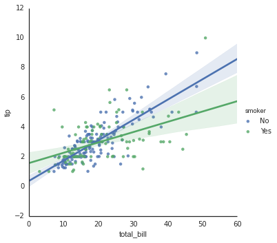

```python
plt.figure(figsize=(7, 7))

sns.lmplot('total_bill', 'tip', tips, hue='smoker')
pass
```

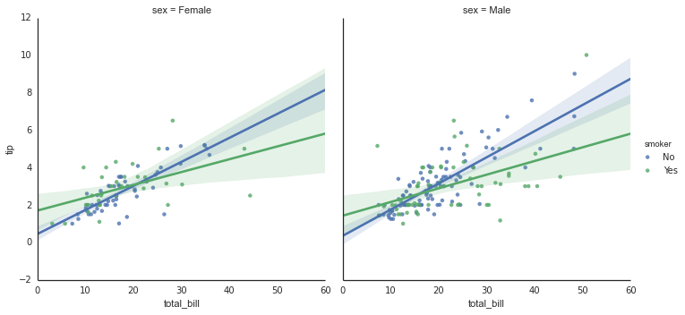

```python
plt.figure(figsize=(10, 7))
sns.lmplot("total_bill", "tip", tips, col='sex', hue='smoker')
pass
```

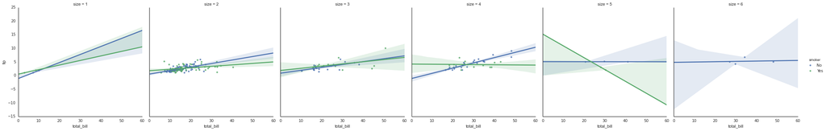

```python
plt.figure(figsize=(17, 7))
sns.lmplot("total_bill", "tip", tips, col='size', hue='smoker')
pass
```

## Quick and dirty flexible barplots

Using pandas, plotting small tables becomes really flexible and straightforward.

```python
m = pd.read_table('table.txt')
m
```

|  | Species | Status | # |
| --- | --- | --- | --- |
| 0 | Ecoli | Unsequenced | 477 |
| 1 | Salmonella | Unsequenced | 200 |
| 2 | Ecoli | Sequenced | 141 |
| 3 | Salmonella | Sequenced | 24 |
| 4 | Bacillus | Sequenced | 290 |

5 rows × 3 columns

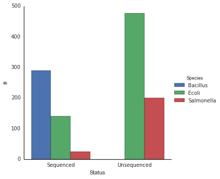

```python
plt.figure(figsize=(10, 10))

sns.factorplot('Status', '#', 'Species', data=m, kind='bar')
sns.despine()
pass
```

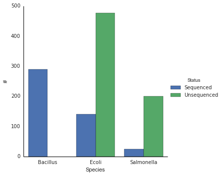

```python
plt.figure(figsize=(10, 10))

sns.factorplot('Species', '#', 'Status', data=m, kind='bar')
sns.despine()
pass
```

## Heatmaps and clustermaps

A recent addition to seaborn are heatmaps and clustermaps; heatmaps were kind of ok with matplotlib, but a dendrogram clustering required extensive knowledge of scipy and lots of creativity.

```python
import pandas as pd
```

```python
# Chemical genomic screen taken from: doi:10.1016/j.cell.2010.11.052
# Note: only a fraction of the total matrix has been used
m = pd.read_table('matrix.tsv')
m.set_index(['Gene'], inplace=True)
```

[figure not shown]

```python
plt.figure(figsize=(10, 10))

sns.heatmap(m)
pass
```

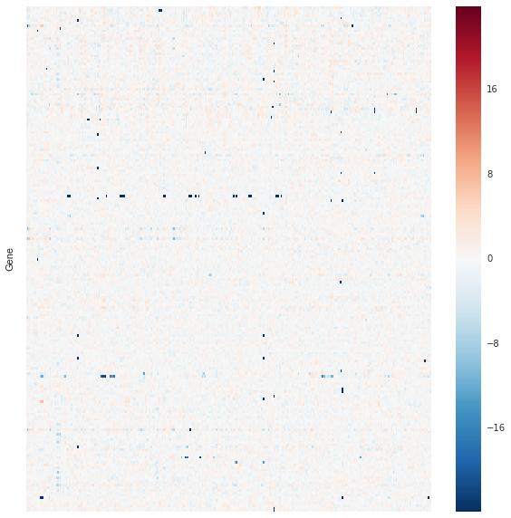

```python
plt.figure(figsize=(10, 10))

sns.heatmap(m,
            # I want to see my data!
            linewidths=0,
            # Also, get rid of the noisy labels
            xticklabels=False,
            yticklabels=False)
pass
```

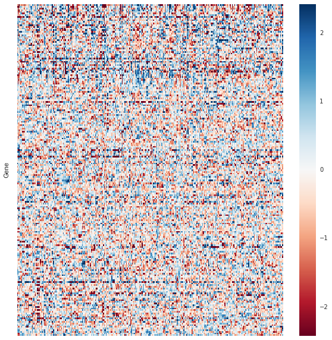

```python
plt.figure(figsize=(10, 10))

sns.heatmap(m,
            # I want to see my data!
            linewidths=0,
            # Also, get rid of the noisy labels
            xticklabels=False,
            yticklabels=False,
            # Also, get a more reasonable range
            # Other possible strategy: use vmin/vmax
            robust=True,
            # If you are one of those people who thinks
            # that blue is for postives
            # you can change the colormap
            cmap=plt.get_cmap('RdBu'))
pass
```

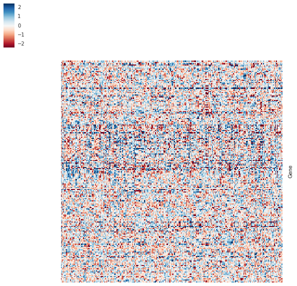

```python
plt.figure(figsize=(10, 10))

clustdata = sns.clustermap(m,
            # I want to see my data!
            linewidths=0,
            # Also, get rid of the noisy labels
            xticklabels=False,
            yticklabels=False,
            robust=True,
            # If you are one of those people who thinks
            # that blue is for postives
            # you can change the colormap
            cmap=plt.get_cmap('RdBu'))
pass
```

```python
# The clustermap function can either use
# scipy or fastcluster for clustering
!sudo pip install fastcluster
```

[output not shown]

[output cut: 8 more lines]

[output not shown]

[figure not shown]

```python
plt.figure(figsize=(10, 10))

clustdata = sns.clustermap(m,
            # I want to see my data!
            linewidths=0,
            # Also, get rid of the noisy labels
            xticklabels=False,
            yticklabels=False,
            robust=True)
pass
```

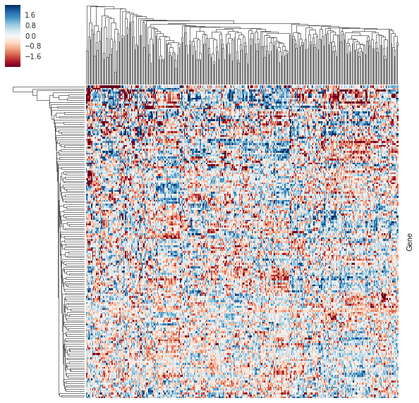

```python
plt.figure(figsize=(10, 10))

# We have to drop the missing values
# or substitute them somehow
# or maybe impute them

clustdata = sns.clustermap(m.dropna(),
            # I want to see my data!
            linewidths=0,
            # Also, get rid of the noisy labels
            xticklabels=False,
            yticklabels=False,
            robust=True,
            # If you are one of those people who thinks
            # that blue is for postives
            # you can change the colormap
            cmap=plt.get_cmap('RdBu'))
pass
```

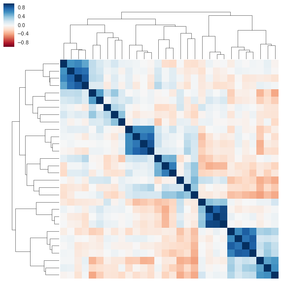

```python
plt.figure(figsize=(10, 10))

# We have to drop the missing values
# or substitute them somehow
# or maybe impute them

# Works very nicely with squared correlation matrices
# Here we are using only a small fraction of the correlation matrix

clustdata = sns.clustermap(m.corr().dropna().as_matrix()[:30, :30],
            # I want to see my data!
            linewidths=0,
            # Also, get rid of the noisy labels
            xticklabels=False,
            yticklabels=False,
            # If you are one of those people who thinks
            # that blue is for postives
            # you can change the colormap
            cmap=plt.get_cmap('RdBu'))
pass
```